# Arboles y Bosques. Ingreso de los hogares

Este es el código para preparar los datos, donde tomamos unas cuantas variables de la encuesta [Enigh 2016](http://www.beta.inegi.org.mx/proyectos/enchogares/regulares/enigh/nc/2016/default.html). **En este caso ignoraremos el hecho de que estos datos resultan de un diseño complejo de muestra**. En este caso, convendría diseñar un esquema de validación apropiado (extrayendo unidades primarias de muestreo completas, por ejemplo), y usar los factores de expansión de la muestra.

```r
library(readr)
library(dplyr)
library(knitr)
concentrado <- read_csv('concentradohogar.csv')
```

[output not shown]

```r
hogares <- read_csv('hogares.csv')
problems(concentrado)
```

| row | col | expected | actual | file |
| --- | --- | --- | --- | --- |
| 1406 | reproducc | no trailing characters | .08 | 'concentradohogar.csv' |
| 1594 | reproducc | no trailing characters | .58 | 'concentradohogar.csv' |
| 2023 | reproducc | no trailing characters | .21 | 'concentradohogar.csv' |
| 2355 | reproducc | no trailing characters | .28 | 'concentradohogar.csv' |
| 2462 | reproducc | no trailing characters | .21 | 'concentradohogar.csv' |
| 4656 | pesca | no trailing characters | .03 | 'concentradohogar.csv' |
| 4846 | reproducc | no trailing characters | .54 | 'concentradohogar.csv' |
| 5669 | pesca | no trailing characters | .13 | 'concentradohogar.csv' |
| 6611 | pesca | no trailing characters | .39 | 'concentradohogar.csv' |
| 7247 | pesca | no trailing characters | .41 | 'concentradohogar.csv' |

[output cut: 436 more lines]

```r
head(concentrado)
```

| folioviv | foliohog | ubica_geo | ageb | tam_loc | est_socio | est_dis | upm | factor | clase_hog | sexo_jefe | edad_jefe | educa_jefe | tot_integ | hombres | mujeres | mayores | menores | p12_64 | p65mas | ocupados | percep_ing | perc_ocupa | ing_cor | ingtrab | trabajo | sueldos | horas_extr | comisiones | aguinaldo | … |
| --- | --- | --- | --- | --- | --- | --- | --- | --- | --- | --- | --- | --- | --- | --- | --- | --- | --- | --- | --- | --- | --- | --- | --- | --- | --- | --- | --- | --- | --- | --- |
| 0100003801 | 1 | 010010001 | 023-3 | 1 | 4 | 003 | 0000010 | 247 | 2 | 1 | 33 | 10 | 2 | 1 | 1 | 2 | 0 | 2 | 0 | 2 | 2 | 2 | 100696.70 | 100696.70 | 100696.70 | 97377.04 | 0 | 0 | 3319.66 | … |
| 0100003802 | 1 | 010010001 | 023-3 | 1 | 4 | 003 | 0000010 | 247 | 2 | 1 | 29 | 10 | 2 | 1 | 1 | 2 | 0 | 2 | 0 | 2 | 2 | 2 | 146616.16 | 144157.15 | 144157.15 | 91475.40 | 0 | 0 | 10819.67 | … |
| 0100003803 | 1 | 010010001 | 023-3 | 1 | 4 | 003 | 0000010 | 247 | 2 | 1 | 47 | 10 | 6 | 2 | 4 | 3 | 3 | 3 | 0 | 1 | 1 | 1 | 94622.95 | 82622.95 | 82622.95 | 82622.95 | 0 | 0 | 0.00 | … |
| 0100003804 | 1 | 010010001 | 023-3 | 1 | 4 | 003 | 0000010 | 247 | 3 | 2 | 29 | 11 | 3 | 0 | 3 | 3 | 0 | 3 | 0 | 2 | 3 | 2 | 58278.65 | 34672.11 | 34672.11 | 33442.61 | 0 | 0 | 1229.50 | … |
| 0100003805 | 1 | 010010001 | 023-3 | 1 | 4 | 003 | 0000010 | 247 | 2 | 1 | 55 | 10 | 2 | 2 | 0 | 2 | 0 | 2 | 0 | 1 | 1 | 1 | 57295.07 | 42295.07 | 42295.07 | 35409.83 | 0 | 0 | 6885.24 | … |
| 0100010401 | 1 | 010010001 | 028-6 | 1 | 4 | 003 | 0000020 | 200 | 3 | 1 | 66 | 10 | 5 | 2 | 3 | 4 | 1 | 2 | 2 | 4 | 4 | 4 | 149554.70 | 30986.39 | 30986.39 | 26706.51 | 0 | 0 | 3546.19 | … |

```r
names(concentrado)
```

```
  [1] "folioviv"   "foliohog"   "ubica_geo"  "ageb"       "tam_loc"
  [6] "est_socio"  "est_dis"    "upm"        "factor"     "clase_hog"
 [11] "sexo_jefe"  "edad_jefe"  "educa_jefe" "tot_integ"  "hombres"
 [16] "mujeres"    "mayores"    "menores"    "p12_64"     "p65mas"
 [21] "ocupados"   "percep_ing" "perc_ocupa" "ing_cor"    "ingtrab"
 [26] "trabajo"    "sueldos"    "horas_extr" "comisiones" "aguinaldo"
 [31] "indemtrab"  "otra_rem"   "remu_espec" "negocio"    "noagrop"
 [36] "industria"  "comercio"   "servicios"  "agrope"     "agricolas"
 [41] "pecuarios"  "reproducc"  "pesca"      "otros_trab" "rentas"
 [46] "utilidad"   "arrenda"    "transfer"   "jubilacion" "becas"
 [51] "donativos"  "remesas"    "bene_gob"   "transf_hog" "trans_inst"
 [56] "estim_alqu" "otros_ing"  "gasto_mon"  "alimentos"  "ali_dentro"
 [61] "cereales"   "carnes"     "pescado"    "leche"      "huevo"
 [66] "aceites"    "tuberculo"  "verduras"   "frutas"     "azucar"
 [71] "cafe"       "especias"   "otros_alim" "bebidas"    "ali_fuera"
 [76] "tabaco"     "vesti_calz" "vestido"    "calzado"    "vivienda"
 [81] "alquiler"   "pred_cons"  "agua"       "energia"    "limpieza"
 [86] "cuidados"   "utensilios" "enseres"    "salud"      "atenc_ambu"
 [91] "hospital"   "medicinas"  "transporte" "publico"    "foraneo"
 [96] "adqui_vehi" "mantenim"   "refaccion"  "combus"     "comunica"
[101] "educa_espa" "educacion"  "esparci"    "paq_turist" "personales"
[106] "cuida_pers" "acces_pers" "otros_gas"  "transf_gas" "percep_tot"
[111] "retiro_inv" "prestamos"  "otras_perc" "ero_nm_viv" "ero_nm_hog"
[116] "erogac_tot" "cuota_viv"  "mater_serv" "material"   "servicio"
[121] "deposito"   "prest_terc" "pago_tarje" "deudas"     "balance"
[126] "otras_erog" "smg"
```

```r
concen_2 <- left_join(concentrado, hogares)
names(concen_2)[1] <- "folioviv"
datos <- concen_2 %>% select(folioviv, foliohog, tam_loc, educa_jefe,
                             celular, tv_paga, conex_inte, num_auto, num_tosta, num_lavad,
                             num_compu, ing_cor, factor) %>%
  mutate(tam_loc = recode(tam_loc, `1`='100 mil+',`2`='15mil-100mil',
                          `3`='2.5mil-15mil',`4`='Menos de 2.5 mil')) %>%
  mutate(celular = recode(celular, `1`='Si', `2`='No')) %>%
  mutate(tv_paga = recode(tv_paga, `1`='Si', `2`='No')) %>%
  mutate(celular = recode(celular, `1`='Si', `2`='No')) %>%
  mutate(conex_inte = recode(conex_inte, `1`='Si', `2`='No'))
#write_csv(datos, path ='vars_enigh_2016.csv')
```

### Datos

Buscamos predecir el ingreso corriente trimestral de los hogares a partir de algunas de sus características, el tamaño de la localidad, y la educación del jefe(a) del hogar. Para este ejemplo usamos una muestra:

```r
set.seed(293)
datos <- read_csv(file = 'vars_enigh_2016.csv')
datos <- sample_n(datos, 10000)
```

Vamos a predecir el log del ingreso. En la escala logarítmica, los cuantiles de ingreso son:

```r
datos$ingreso_log <- log(1 + datos$ing_cor)
#escala log
quantile(datos$ingreso_log, probs = seq(0,1,0.1))
```

```
       0%       10%       20%       30%       40%       50%       60%       70%
 0.000000  9.337049  9.689651  9.925379 10.125587 10.309623 10.496600 10.704291
      80%       90%      100%
10.957557 11.293807 15.263128
```

Y en la escala original (recuerda que es ingreso **trimestral**):

```r
#escala original
exp(quantile(datos$ingreso_log, probs = seq(0,1,0.1)))
```

```
        0%        10%        20%        30%        40%        50%        60%
      1.00   11350.86   16149.60   20442.66   24973.90   30020.10   36192.25
       70%        80%        90%       100%
  44546.57   57386.08   80322.63 4252971.16
```

### Árboles

Corre el siguiente código

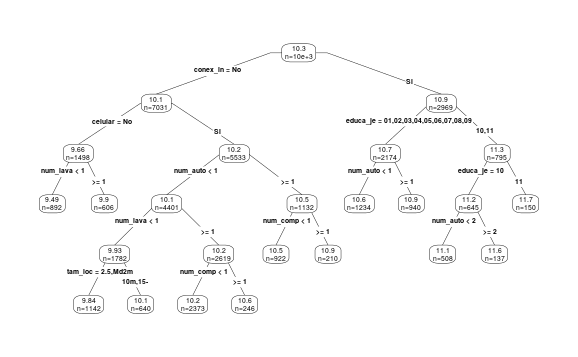

```r
library(rpart)
library(rpart.plot)
arbol_grande <- rpart(ingreso_log ~ tam_loc + educa_jefe +
                        celular+ conex_inte + num_auto+ num_tosta+ num_lavad+ num_compu + factor,
                      data= datos, cp=0)
prp(prune(arbol_grande, cp=0.004), type=4, extra=1, digits=3)
```

1. ¿Qué significa la información que hay en cada nodo? Nota: puedes interpretar diferencias de log ingreso rápidamente si tomas en cuenta que una diferencia en la escala logarítmica (para diferencias más chicas) es aproximadamente cambio porcentual en ingreso. Por ejemplo la diferencia de ingreso en escala log de 4.7 a 4.9 es aproximadamente un incremento de 20%.

Los nodos contienen el valor promedio de ingreso en escala log y el número de hogares que se encuentran en cada nodo. En el nodo inicial se tiene como valor predictivo 10.3, que sería el valor que obtendríamos en escala log del ingreso si no contaramos con información adicional, a partir de ahí, la variable conexión a internet divide en dos grupos, si cuentan con conexión el ingreso trimestral promedio es de $54176.36, mientras que si no se tiene conexión a internet el salario promedio es $24343.01, menos de la mitad del otro grupo. El grupo sin conexión a internet se subdivide dependiendo de si se tiene celular, mientras que en el grupo con conexión a internet se hace una nueva separación dependiendo del la educación del jefe de familia. Se puede seguir la subdivisión hasta que se tienen 13 nodos finales. Por ejemplo el sexto nodo da un ingreso en escala log de 10.6 que corresponde a un hogar sin conexión a internet, tienen celular, no tienen autos, tienen al menos una lavadora y al menos una computadora, hay 246 hogares con estas características. El nodo 9 tiene el mismo ingreso de 10.6, y es un hogar con conexión a internet, donde el jefe de familia tiene educación menor al nivel 10 y no tienen auto, hay 1234 hogares con estas características.

2. Poda el árbol para mostrar solamente un árbol con 5 nodos terminales. ¿Qué variables son usadas? Evalúa el error de entrenamiento para este árbol.

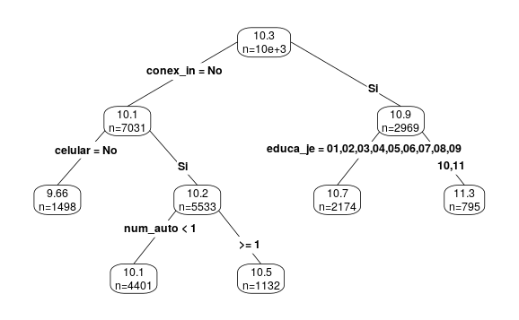

```r
arbol_5_nodos <- prune(arbol_grande, cp=0.025)
prp(prune(arbol_grande, cp=0.025), type=4, extra=1, digits=3)
```

Con un parámetro de complejidad de 0.025, el árbol podado tiene 5 nodos terminales. Las variables usadas son conexión a internet, uso de celular, educación del jefe de familia y número de autos.

```r
Pred_ent <- predict(arbol_5_nodos)
mean((datos$ingreso_log - Pred_ent)^2)
```

```
[1] 0.419654
```

El error como $\frac{1}{N}\sum (y_i-\hat{y_i})^2$ da un error de 0.42.

### Bosques aleatorios

1. Usa un bosque aleatorio para predecir el log ingreso. Prueba algunos valores de $m$ (mtry) y escoge un modelo final usando el error out-of-bag. Grafica cómo evoluciona la estimación OOB del error conforme aumenta el número de árboles.

Usamos la librería randomForest

```r
library(randomForest)
set.seed(1832)
```

```r
library(tidyr)
#utiliza estos datos, que tienen las variables categóricas convertidas a factores.
datos_df <- data.frame(unclass(datos))
datos_df <- datos_df %>% select(-c("folioviv", "foliohog","ing_cor", "factor"))
```

```r
MSEs <- c()
for(i in 1:6){
  rF1  <- randomForest(formula = (ingreso_log) ~.,
                      data = datos_df, ntree = 50, mtry = i, importance = TRUE)
  MSEs <- c(MSEs, mean(rF1$mse))
}
```

```r
MSEs2 <- c()
for(i in 10:1000){
   rF1  <- randomForest(formula = (ingreso_log) ~.,
                      data = datos_df, ntree = i, mtry = 2, importance = TRUE)
  MSEs2 <- c(MSEs2, mean(rF1$mse))
}
```

2. Examina las importancias de las variables. ¿Cuáles son las 2 variables más importantes?
3. (Opcional) Incluye una o dos variables adicionales que crees que puedan tener importancia alta. ¿En qué lugar aparecen?